# Análisis Exploratorio de Datos

- Mostrar todo el código
- Ocultar todo el código
- Ver el código fuente

Encuesta de hábitos — Estadística Aplicada

Autor/a

Álvaro Mattus Donaire

Fecha de publicación

29 de abril de 2026

## 1 Contexto y objetivo

Este análisis usa datos recolectados en clase mediante una encuesta breve. El objetivo no es solo obtener resultados, sino recorrer el proceso completo de un análisis exploratorio: cargar datos, limpiarlos, visualizarlos e interpretarlos.

La pregunta central que guía el análisis es:

> ¿Qué patrones de hábitos (sueño, estudio, uso de redes) se observan en estudiantes universitarios, y cómo se relacionan con variables como trabajar o el medio de transporte?

**ImportanteAntes de empezar: el tamaño importa**

La muestra es de *n = 27 estudiantes.* Todo lo que se observa aquí es *descriptivo* — describe a este grupo en este momento. No podemos generalizar a toda la población estudiantil ni hacer inferencias formales sin pruebas estadísticas adicionales. Veremos esto más adelante en el curso.

## 2 Carga y preparación de datos

Lo primero siempre es cargar y revisar la estructura de los datos

**Código**

```r
datos <- read_excel("Dudas(1-27).xlsx") |>
  select(
    sueno      = `¿Cuántas horas dormiste anoche?`,
    traslado   = `¿Cuánto tardas en llegar a la U? (En minutos)`,
    apps       = `¿Cuántas apps tienes instaladas en tu celular aprox?`,
    estatura   = `¿Cuál es tu estatura? (En centímetros)`,
    redes      = `¿Cuántas horas al día usas redes sociales en promedio?`,
    estudio    = `¿Cuántas horas a la semana en promedio estudias fuera de clases?`,
    transporte = `¿Cómo llegas a la U? (Último tramo)`,
    trabaja    = `¿Tienes trabajo remunerado además de estudiar?`
  ) |>
  mutate(
    trabaja    = factor(trabaja),
    transporte = factor(transporte),
    across(c(sueno, traslado, apps, estatura, redes, estudio), as.numeric)
  )
```

### 2.1 Inspección inicial

Antes de cualquier análisis, debemos revisar las dimensiones de los datos, qué tipos de variables hay presentes y si hay valores faltantes o extremos. Es fácil olvidarse de hacer esto, pero es mala idea porque influirá en el análisis posterior.

**Código**

```r
glimpse(datos)
```

```
Rows: 27
Columns: 8
$ sueno      <dbl> 7.0, 7.0, 6.0, 3.0, 9.0, 5.0, 8.0, 5.0, 7.0, 4.0, 7.0, 4.0,…
$ traslado   <dbl> 30, 15, 30, 120, 120, 60, 90, 90, 90, 10, 80, 120, 100, 120…
$ apps       <dbl> 60, 15, 40, 168, 25, 54, 30, 50, 5, 150, 20, 20, 30, 90, 60…
$ estatura   <dbl> 180.00, 169.00, 162.00, 178.00, 163.00, 180.00, 170.00, 170…
$ redes      <dbl> 5.0, 3.0, 6.0, 2.0, 5.0, 2.0, 3.0, 3.0, 4.0, 3.0, 4.0, 5.0,…
$ estudio    <dbl> 1, 25, 3, 5, 5, 18, 16, 2, 2, 12, 8, 10, 2, 4, 4, 10, 3, 6,…
$ transporte <fct> Auto, Auto, Auto, Micro, Micro, Bus de acercamiento, Micro,…
$ trabaja    <fct> Sí, No, No, No, Sí, Sí, No, No, No, Sí, No, Sí, No, No, No,…
```

**Código**

```r
datos |>
  summarise(across(everything(), ~ sum(is.na(.)))) |>
  pivot_longer(everything(), names_to = "variable", values_to = "NA_count")
```

```
# A tibble: 8 × 2
  variable   NA_count
  <chr>         <int>
1 sueno             0
2 traslado          0
3 apps              0
4 estatura          0
5 redes             0
6 estudio           0
7 transporte        0
8 trabaja           0
```

**NotaInterpretación**

No hay valores faltantes en ninguna variable. En una encuesta respondida en clase eso es esperable porque el contexto presencial reduce la tasa de no respuesta.

### 2.2 Limpieza

Algunos valores son claramente erróneos. Por ejemplo, estaturas menores a 100 cm no corresponden a personas adultas.

**Código**

```r
datos <- datos |>
  filter(estatura > 100)
```

**AdvertenciaPara discutir**

¿Qué criterio usamos para decidir que un dato es un *error* y no solo un *valor atípico?* Una estatura de 50 cm es imposible en un adulto, así que la eliminamos. Pero un estudiante que dice estudiar 25 horas semanales, ¿es un error o simplemente un caso extremo? La diferencia es importante porque los errores los eliminamos, pero los valores atípicos se conservan y se menciona qué los hace atípicos. Lo conveniente es tener una regla de decisión previamente determinada.

### 2.3 Resumen estadístico

Un resumen estadístico nos muestra una primera aproximación a los datos. Esto nos da una idea de rangos, medias y posibles anomalías, como valores extremos.

**Código**

```r
skim(datos)
```

Data summary

| Name | datos |
| --- | --- |
| Number of rows | 26 |
| Number of columns | 8 |
| _______________________ |  |
| Column type frequency: |  |
| factor | 2 |
| numeric | 6 |
| ________________________ |  |
| Group variables | None |

**Variable type: factor**

| skim_variable | n_missing | complete_rate | ordered | n_unique | top_counts |
| --- | --- | --- | --- | --- | --- |
| transporte | 0 | 1 | FALSE | 4 | Mic: 16, Bus: 5, Aut: 4, A p: 1 |
| trabaja | 0 | 1 | FALSE | 2 | No: 18, Sí: 8 |

**Variable type: numeric**

| skim_variable | n_missing | complete_rate | mean | sd | p0 | p25 | p50 | p75 | p100 | hist |
| --- | --- | --- | --- | --- | --- | --- | --- | --- | --- | --- |
| sueno | 0 | 1 | 6.37 | 1.60 | 3.0 | 5.0 | 6.25 | 7.00 | 9 | ▃▇▇▇▇ |
| traslado | 0 | 1 | 74.62 | 34.70 | 10.0 | 50.0 | 85.00 | 97.50 | 120 | ▅▃▃▇▇ |
| apps | 0 | 1 | 67.38 | 54.29 | 5.0 | 30.0 | 45.00 | 90.00 | 200 | ▇▃▂▂▁ |
| estatura | 0 | 1 | 172.81 | 9.01 | 152.0 | 167.5 | 173.50 | 179.75 | 190 | ▁▆▇▇▃ |
| redes | 0 | 1 | 4.37 | 2.70 | 0.5 | 3.0 | 4.00 | 5.00 | 15 | ▇▇▁▁▁ |
| estudio | 0 | 1 | 7.12 | 5.62 | 1.0 | 3.0 | 5.50 | 8.00 | 25 | ▇▆▁▁▁ |

**NotaQué observar en esta tabla**

1. El rango de cada variable — ¿hay valores que no tienen sentido?
2. La diferencia entre media y mediana — si son muy distintas, hay sesgo-
3. La variable `apps` muestra una media notablemente mayor que la mediana, lo que anticipa que hay al menos un valor muy alto que lleva la media hacia arriba.

## 3 Variables cualitativas

Las variables cualitativas se resumen generalmente con frecuencias absolutas. El gráfico de barras es el gráfico estándar.

### 3.1 Medio de transporte

**Código**

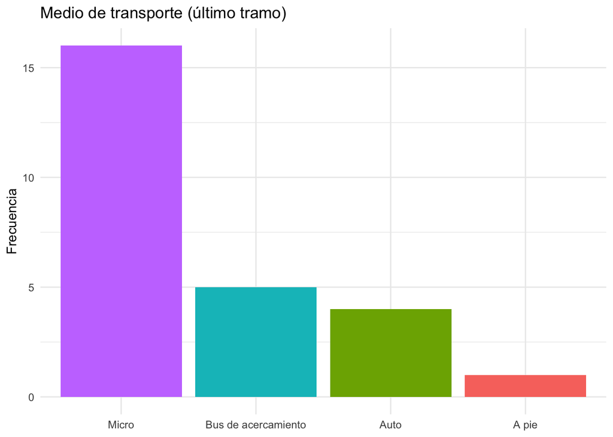

Figura 1: Frecuencia de cada medio de transporte

```r
ggplot(datos, aes(x = fct_infreq(transporte), fill = transporte)) +
  geom_bar() +
  labs(title = "Medio de transporte (último tramo)", x = NULL, y = "Frecuencia") +
  theme_minimal() +
  theme(legend.position = "none")
```

**NotaInterpretación**

La micro es el medio más frecuente, seguida por bus de acercamiento y auto.

Esta distribución es relevante para interpretar los tiempos de traslado que aparecen más adelante, porque los grupos no son del mismo tamaño.

### 3.2 Trabajo remunerado

**Código**

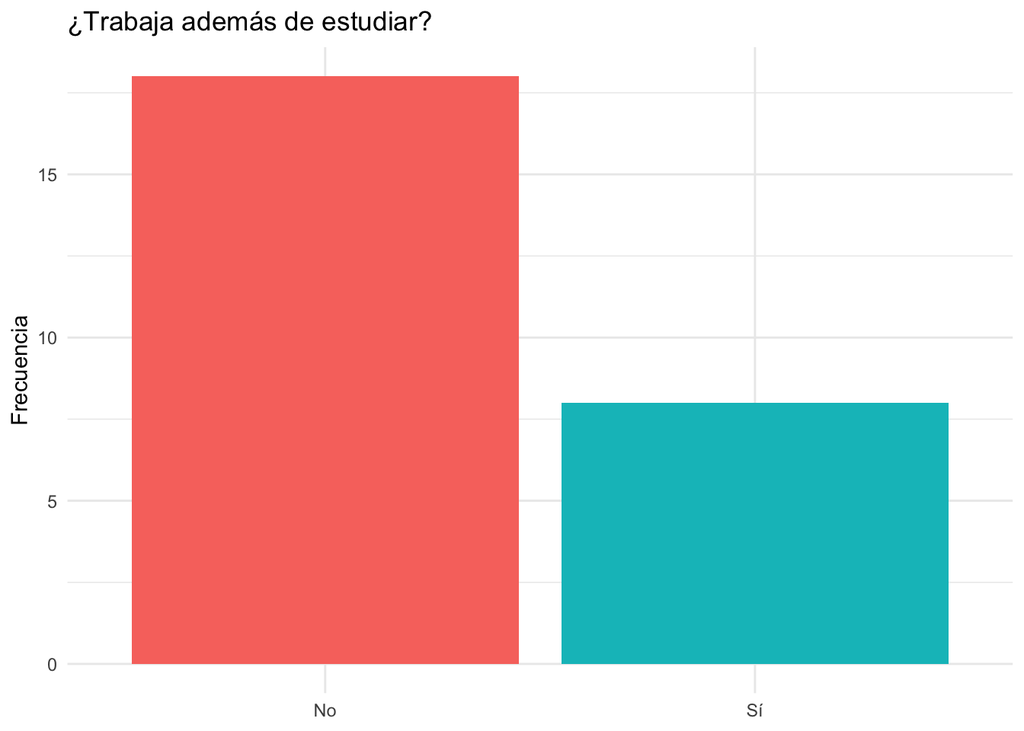

Figura 2: Proporción de estudiantes con trabajo remunerado

```r
ggplot(datos, aes(x = trabaja, fill = trabaja)) +
  geom_bar() +
  labs(title = "¿Trabaja además de estudiar?", x = NULL, y = "Frecuencia") +
  theme_minimal() +
  theme(legend.position = "none")
```

**NotaInterpretación**

Aproximadamente un tercio de las personas que respondieron trabaja. Es suficiente para comparar hábitos entre grupos, aunque con $n$ pequeño los resultados hay que tomarlos con cuidado.

## 4 Variables cuantitativas: distribución univariada

Para cada variable cuantitativa, queremos responder tres preguntas:

1. ¿Dónde está el centro?
2. ¿Qué tan dispersos están los datos?
3. ¿Tiene la distribución alguna forma particular (sesgo, más de una moda)?

Usamos histogramas y boxplots. Empezamos sin marcas para leer la forma, luego agregamos media y mediana.

### 4.1 Funciones auxiliares

**Código**

```r
marcas <- function(var) {
  datos |>
    summarise(
      media   = mean({{ var }}, na.rm = TRUE),
      mediana = median({{ var }}, na.rm = TRUE)
    )
}

hist_simple <- function(var, etiqueta) {
  ggplot(datos, aes(x = {{ var }})) +
    geom_histogram(bins = 10, fill = "steelblue", color = "white") +
    labs(title = etiqueta, x = etiqueta, y = "Frecuencia") +
    theme_minimal()
}

hist_marcas <- function(var, etiqueta) {
  m <- marcas({{ var }})
  ggplot(datos, aes(x = {{ var }})) +
    geom_histogram(bins = 10, fill = "steelblue", color = "white") +
    geom_vline(xintercept = m$media,   color = "red",    linewidth = 1) +
    geom_vline(xintercept = m$mediana, color = "orange", linewidth = 1,
               linetype = "dotted") +
    annotate("text", x = m$media,   y = Inf, label = "media",
             color = "red",    vjust = 2, hjust = -0.1, size = 3.5) +
    annotate("text", x = m$mediana, y = Inf, label = "mediana",
             color = "orange", vjust = 2, hjust = -0.1, size = 3.5) +
    labs(title = etiqueta, x = etiqueta, y = "Frecuencia") +
    theme_minimal()
}
```

### 4.2 Vista general

Un primer vistazo a todas las variables a la vez:

**Código**

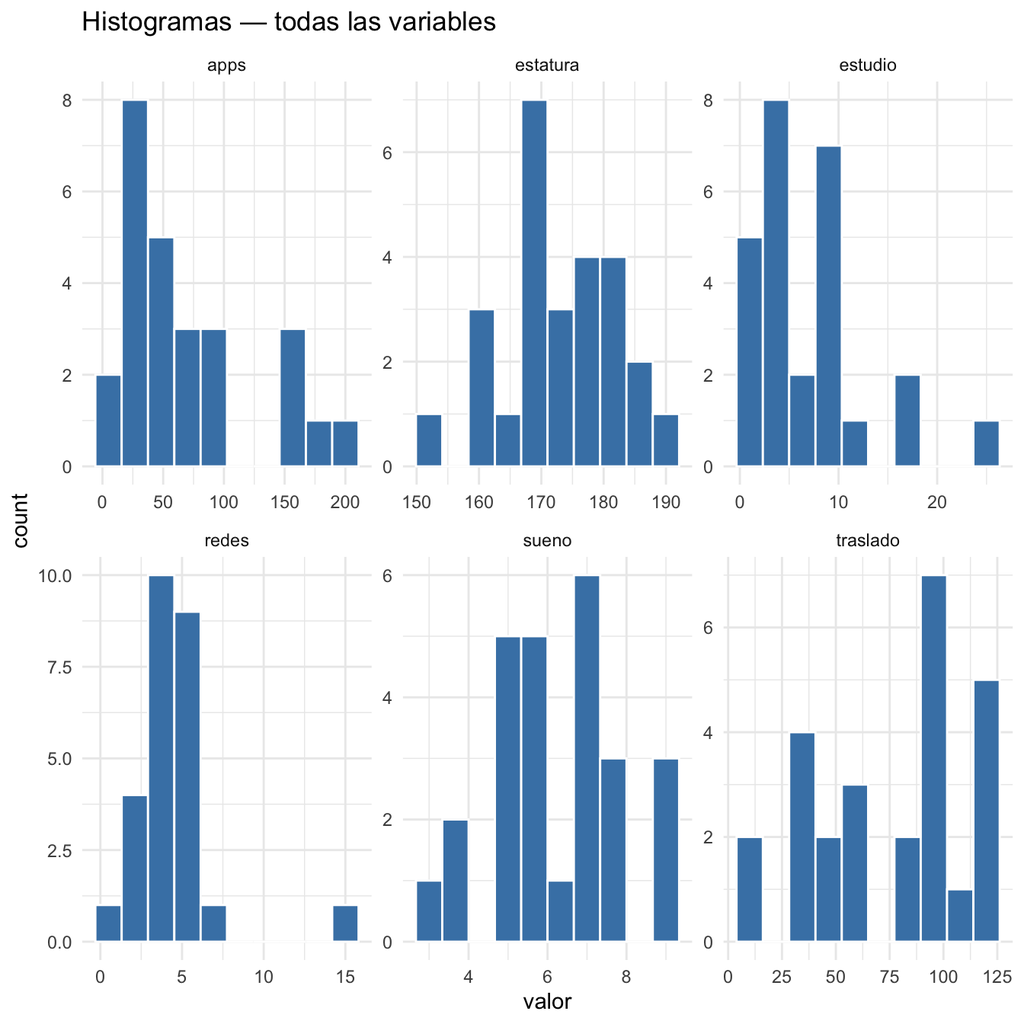

Figura 3: Histogramas de todas las variables numéricas

```r
datos |>
  select(where(is.numeric)) |>
  pivot_longer(everything(), names_to = "variable", values_to = "valor") |>
  ggplot(aes(x = valor)) +
  geom_histogram(bins = 10, fill = "steelblue", color = "white") +
  facet_wrap(~variable, scales = "free") +
  labs(title = "Histogramas — todas las variables") +
  theme_minimal()
```

**NotaInterpretación**

### 4.3 Análisis variable a variable

#### 4.3.1 Horas de sueño

**Código**

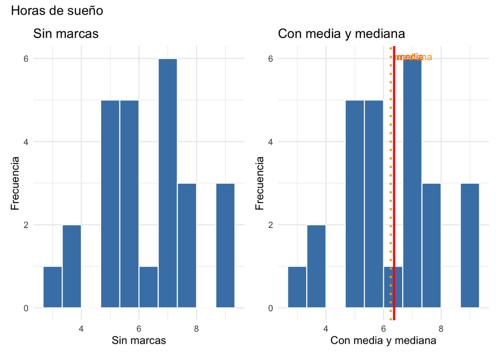

Figura 4: Horas de sueño — sin y con marcas de posición central

```r
p1 <- hist_simple(sueno, "Sin marcas")
p2 <- hist_marcas(sueno, "Con media y mediana")
p1 + p2 + plot_annotation(title = "Horas de sueño")
```

**NotaInterpretación**

Media y mediana coinciden cerca de las 6–7 horas — distribución relativamente simétrica. El rango va de 3 a 9 horas. Para una población universitaria, una mediana de 6–7 horas está levemente por debajo de las 8 horas recomendadas.

#### 4.3.2 Tiempo de traslado

**Código**

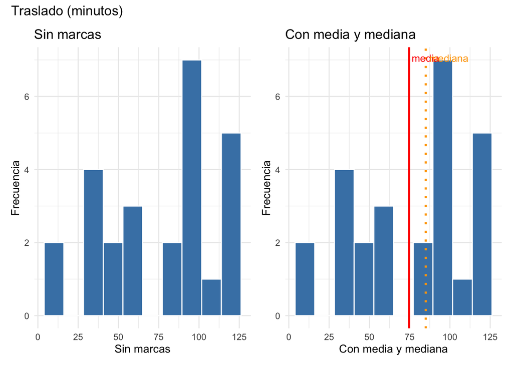

Figura 5: Tiempo de traslado — sin y con marcas de posición central

```r
p3 <- hist_simple(traslado, "Sin marcas")
p4 <- hist_marcas(traslado, "Con media y mediana")
p3 + p4 + plot_annotation(title = "Traslado (minutos)")
```

**NotaInterpretación**

Esta distribución tiene forma *bimodal:* hay un grupo que demora entre 30 y 60 min y otro que demora entre 90 y 120 min. No es que haya sesgo, si no que son dos subgrupos distintos, probablemente auto vs micro. La media (~75 min) no representa bien a nadie porque cae entre los dos grupos. Este es un buen ejemplo de por qué la media puede ser engañosa.

#### 4.3.3 Aplicaciones instaladas

**Código**

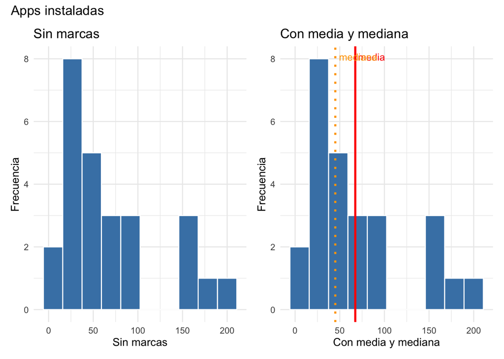

Figura 6: Apps instaladas — sin y con marcas de posición central

```r
p5 <- hist_simple(apps, "Sin marcas")
p6 <- hist_marcas(apps, "Con media y mediana")
p5 + p6 + plot_annotation(title = "Apps instaladas")
```

**NotaInterpretación**

#### 4.3.4 Curva de densidad: estatura

El histograma depende del número de bins. La curva de densidad da una visión más suave de la forma de la distribución.

**Código**

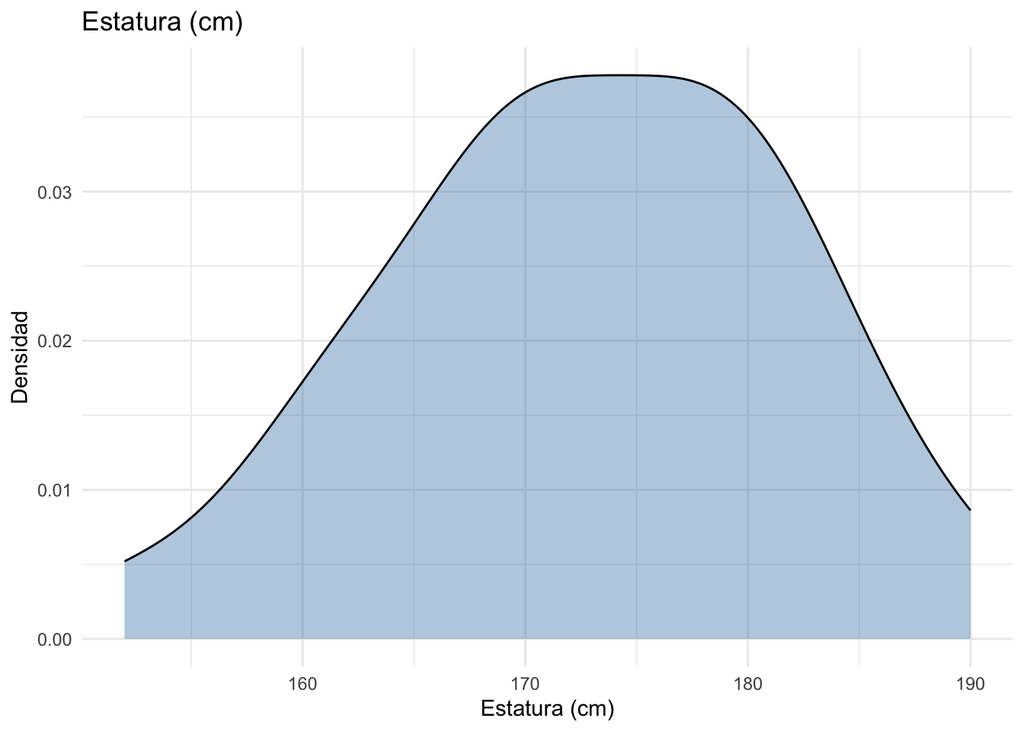

Figura 7: Curva de densidad — estatura

```r
ggplot(datos, aes(x = estatura)) +
  geom_density(fill = "steelblue", alpha = 0.4) +
  labs(title = "Estatura (cm)", x = "Estatura (cm)", y = "Densidad") +
  theme_minimal()
```

**NotaInterpretación**

La distribución de estaturas tiene forma aproximadamente normal, centrada cerca de 170–172 cm. Es divertido que incluso en muestras pequeñas, como la que tenemos, tiende a aparecer una forma relativamente cercana a la campana. En un curso con una proporción más cercana a $1:1$ entre hombres y mujeres probablemente veríamos algo más bimodal.

## 5 Dispersión y valores atípicos: boxplots

El boxplot muestra cuartiles, rango intercuartílico y valores atípicos de un vistazo. Lo usamos cuando queremos comparar dispersión, no solo centro.

### 5.1 Funciones auxiliares

**Código**

```r
box_simple <- function(var, etiqueta) {
  ggplot(datos, aes(x = {{ var }})) +
    geom_boxplot(fill = "steelblue", width = 0.4) +
    labs(title = etiqueta, x = etiqueta) +
    theme_minimal() +
    theme(axis.text.y = element_blank(), axis.ticks.y = element_blank())
}

box_con_media <- function(var, etiqueta) {
  m <- marcas({{ var }})
  ggplot(datos, aes(x = {{ var }})) +
    geom_boxplot(fill = "steelblue", width = 0.4) +
    annotate("point", y = 0, x = m$media, color = "red", size = 3, shape = 18) +
    labs(title = etiqueta, subtitle = "◆ media", x = etiqueta) +
    theme_minimal() +
    theme(axis.text.y = element_blank(), axis.ticks.y = element_blank())
}
```

### 5.2 Vista general

**Código**

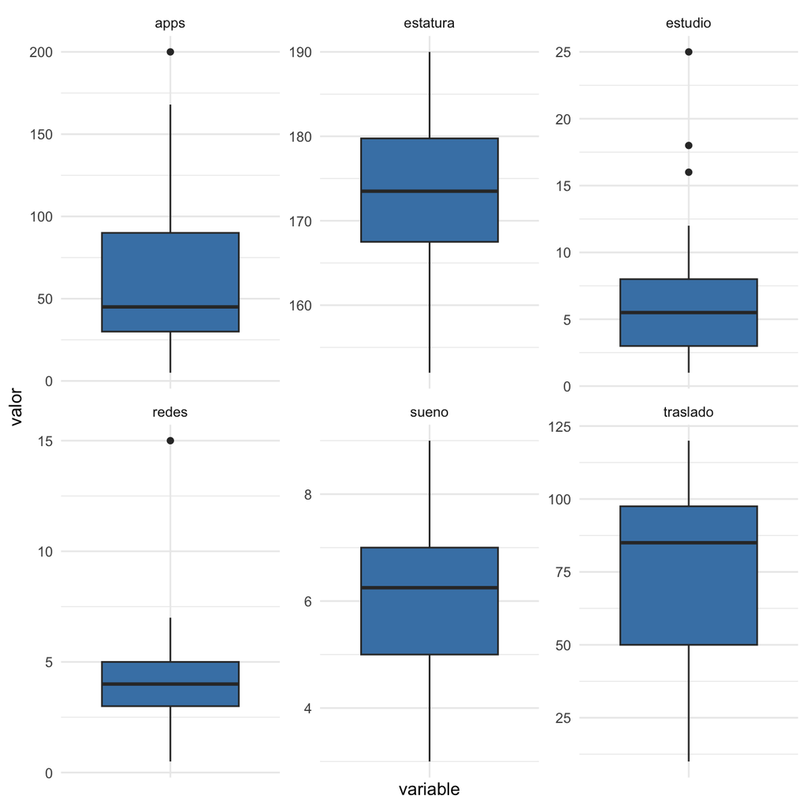

Figura 8: Boxplots de todas las variables numéricas

```r
datos |>
  select(where(is.numeric)) |>
  pivot_longer(everything(), names_to = "variable", values_to = "valor") |>
  ggplot(aes(x = variable, y = valor)) +
  geom_boxplot(fill = "steelblue") +
  facet_wrap(~variable, scales = "free") +
  theme_minimal() +
  theme(axis.text.x = element_blank())
```

### 5.3 Comparación con y sin media

Agregar la media al boxplot permite ver si está desplazada respecto a la mediana, lo que indica asimetría.

**Código**

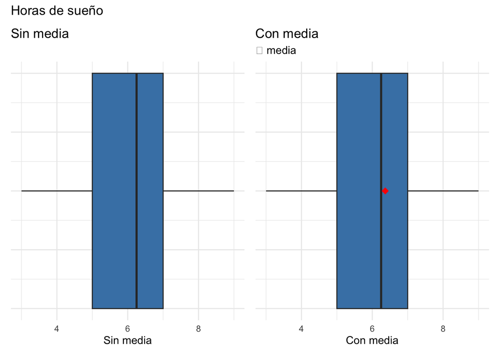

Figura 9: Boxplot de horas de sueño — con y sin media

```r
p7 <- box_simple(sueno, "Sin media")
p8 <- box_con_media(sueno, "Con media")
p7 + p8 + plot_annotation(title = "Horas de sueño")
```

**NotaInterpretación**

## 6 Análisis bivariado: ¿quién duerme más, quién estudia más?

Ahora podemos mezclar variables para buscar relaciones. La pregunta que hacemos siempre es *¿importa el grupo al que pertenece una persona?*

### 6.1 Variables numéricas según trabaja/no trabaja

**Código**

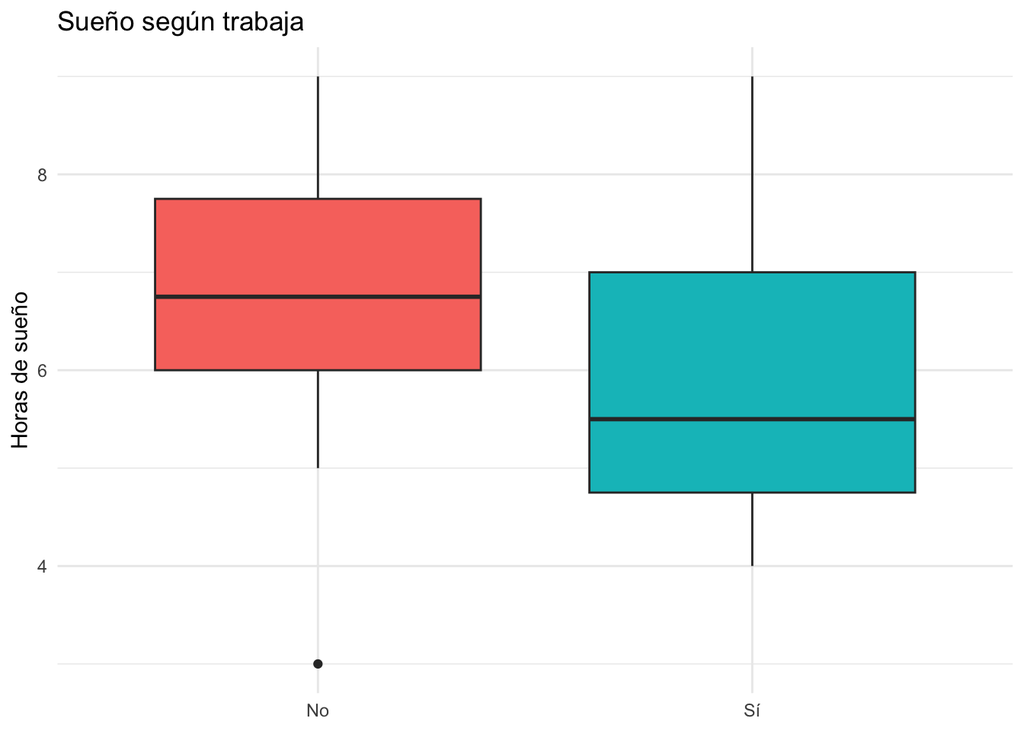

Figura 10: Horas de sueño según trabaja

```r
ggplot(datos, aes(x = trabaja, y = sueno, fill = trabaja)) +
  geom_boxplot() +
  labs(title = "Sueño según trabaja", x = NULL, y = "Horas de sueño") +
  theme_minimal() +
  theme(legend.position = "none")
```

**NotaInterpretación**

Los que trabajan duermen levemente menos, aunque los rangos se superponen un montón: hay estudiantes que trabajan y duermen harto y estudiantes que no trabajan y duermen poco. La diferencia existe pero no es dramática. Para saber si realmente hay una diferencia con cierta confianza deberíamos tener más datos.

**Código**

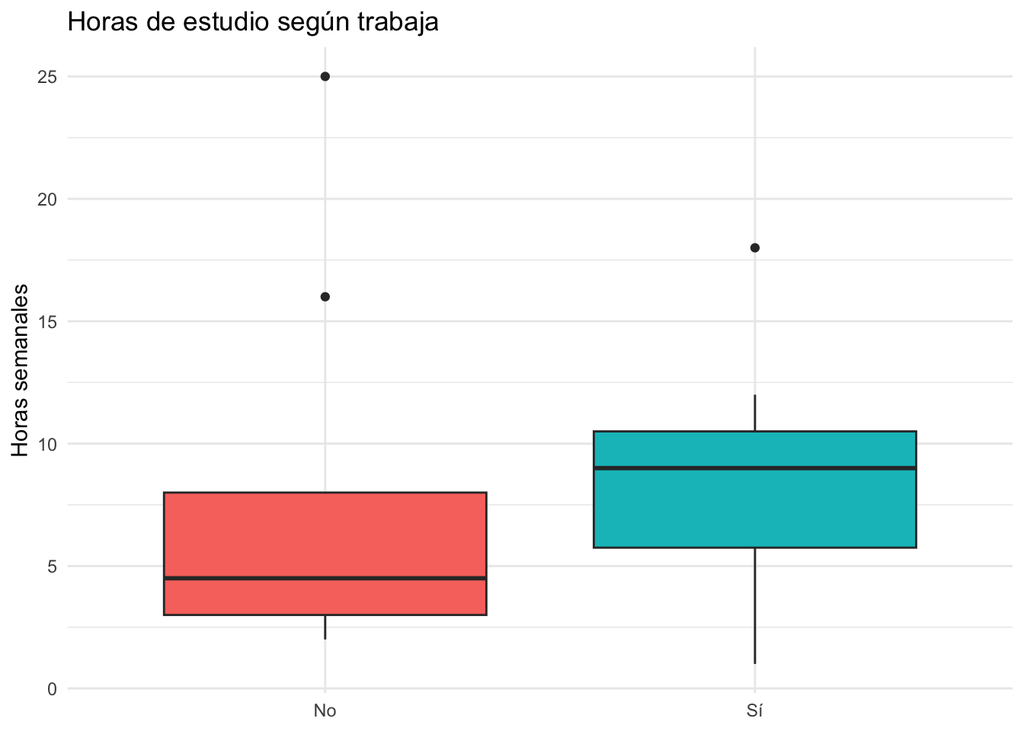

Figura 11: Horas de estudio semanal según trabaja

```r
ggplot(datos, aes(x = trabaja, y = estudio, fill = trabaja)) +
  geom_boxplot() +
  labs(title = "Horas de estudio según trabaja", x = NULL, y = "Horas semanales") +
  theme_minimal() +
  theme(legend.position = "none")
```

**NotaInterpretación**

Este resultado puede ser contraintuitivo: los que trabajan estudian *más* horas semanales que los que no trabajan (mediana ~10 vs ~5). ¿Qué significa? ¿Los que no trabajan son más flojos? Hay que tener cuidado en no responder más de lo que podemos abarcar. En este caso, los conceptos como flojera son difíciles de operacionalizar y también es muy difícil encontrar relaciones *causales* además de simplemente correlaciones. Además, como nuestro $n$ es pequeño, el haber tenido quizás una muestra un poco exótica se hace más visible.

**Código**

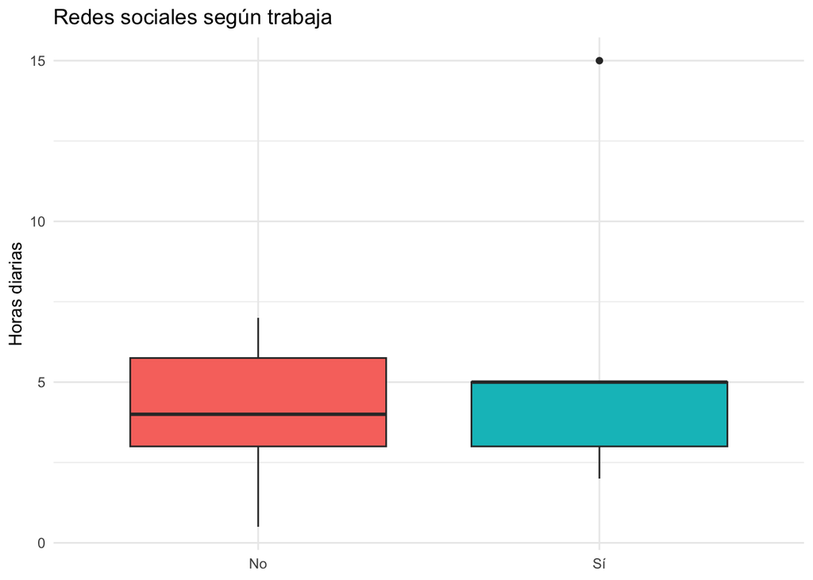

Figura 12: Uso de redes sociales según trabaja

```r
ggplot(datos, aes(x = trabaja, y = redes, fill = trabaja)) +
  geom_boxplot() +
  labs(title = "Redes sociales según trabaja", x = NULL, y = "Horas diarias") +
  theme_minimal() +
  theme(legend.position = "none")
```

**NotaInterpretación**

No hay diferencia clara en el uso de redes sociales entre los dos grupos. Trabajar no parece estar asociado con menos (ni más) tiempo en redes sociales.

### 6.2 Traslado según medio de transporte

**Código**

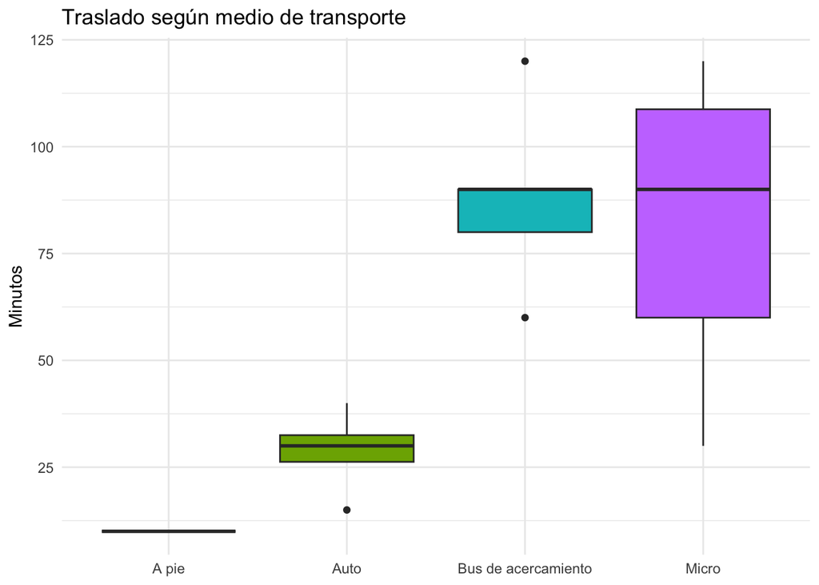

Figura 13: Tiempo de traslado según medio de transporte

```r
ggplot(datos, aes(x = transporte, y = traslado, fill = transporte)) +
  geom_boxplot() +
  labs(title = "Traslado según medio de transporte",
       x = NULL, y = "Minutos") +
  theme_minimal() +
  theme(legend.position = "none")
```

**NotaInterpretación**

La micro además tiene mayor dispersión. Nuestra experiencia nos muestra que el tiempo en bus es menos predecible. Esto muestra por qué es importante hacer un análisis bivariado: `transporte` en univariado se veía raro, pero ahora podemos ver que tiene varios subgrupos bien distintos.

## 7 Relaciones entre variables numéricas: diagramas de dispersión

El scatterplot permite ver si dos variables numéricas están relacionadas. La línea de tendencia (por ahora) es sólo una referencia visual.

**Código**

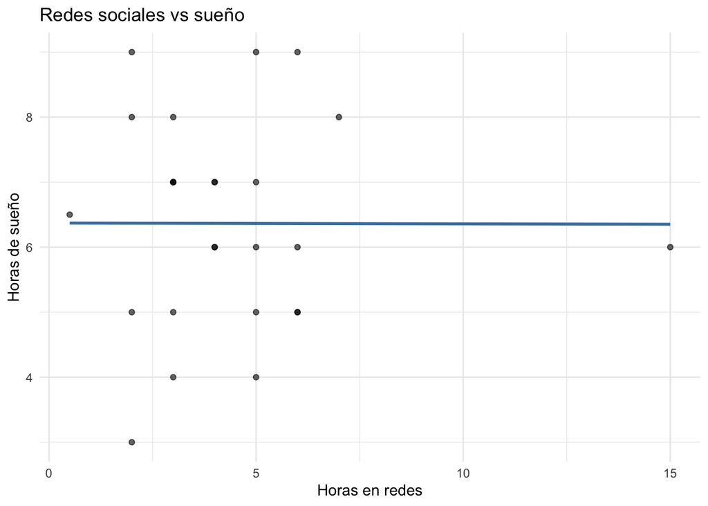

Figura 14: Relación entre uso de redes sociales y horas de sueño

```r
ggplot(datos, aes(x = redes, y = sueno)) +
  geom_point(alpha = 0.6) +
  geom_smooth(method = "lm", se = FALSE, color = "steelblue") +
  labs(title = "Redes sociales vs sueño",
       x = "Horas en redes", y = "Horas de sueño") +
  theme_minimal()
```

**NotaInterpretación**

La línea de tendencia es prácticamente horizontal, así que para estos datos podríamos suponer que no hay relación visible entre horas en redes y horas de sueño. Esto también es un resultado. A veces el análisis exploratorio muestra que dos variables que *intuitivamente* parecen relacionadas (más redes → menos sueño) no muestran ese patrón en los datos.

**Código**

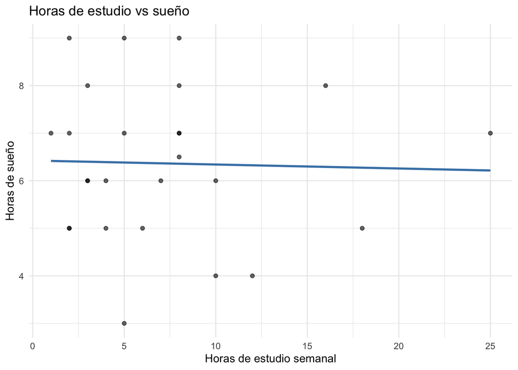

Figura 15: Relación entre horas de estudio y horas de sueño

```r
ggplot(datos, aes(x = estudio, y = sueno)) +
  geom_point(alpha = 0.6) +
  geom_smooth(method = "lm", se = FALSE, color = "steelblue") +
  labs(title = "Horas de estudio vs sueño",
       x = "Horas de estudio semanal", y = "Horas de sueño") +
  theme_minimal()
```

**NotaInterpretación**

**Código**

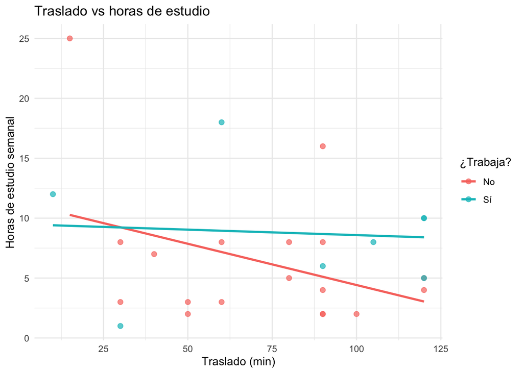

Figura 16: Traslado vs horas de estudio, separado por trabaja

```r
ggplot(datos, aes(x = traslado, y = estudio, color = trabaja)) +
  geom_point(alpha = 0.7, size = 2) +
  geom_smooth(method = "lm", se = FALSE) +
  labs(title = "Traslado vs horas de estudio",
       x = "Traslado (min)", y = "Horas de estudio semanal",
       color = "¿Trabaja?") +
  theme_minimal()
```

**NotaInterpretación**

## 8 Resumen y próximos pasos

**ImportanteHallazgos principales**

El análisis exploratorio es un punto de partida. Su intención es hacernos ver cómo “funcionan” las variables por sí mismas, qué relaciones podría haber entre ellas, cómo se influencian entre sí. Pero no es el final. Podemos cuantificar las relaciones que encontramos, por ejemplo usando regresión lineal. También podemos ver si hay diferencias *estadísticamente significativas* (más detalles sobre eso pronto) usando pruebas de hipótesis u otras técnicas. Lo que sí nos ayuda es a proponer(nos) conjeturas, que luego trataremos de verificar con las técnicas que mencionaba (entre muchas, muchas, otras).